# A quick exploration of the National Vegetation Database

Jasper Slingsby

25 October 2016

**Lets have a look at the basic stats**

Number of plots altogether = 53499

Number of plots with spatial data = 33401

Number of unique species names = 50849 - lots if issues there!

Number of unique genus names = 6143 - suspicious too…

Number of species by site observations = 1152987

Below we see the spatial distribution of plots, with larger circles indicating poor location confidence, and red plots falling in the sea:

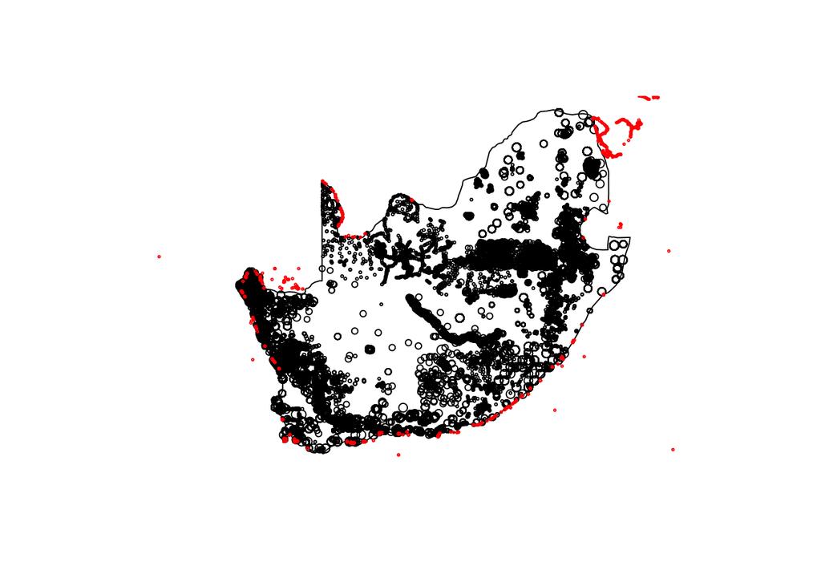

Clearly there are large gaps, and lost of spatial inaccuracy!

The distribution of studies by year:

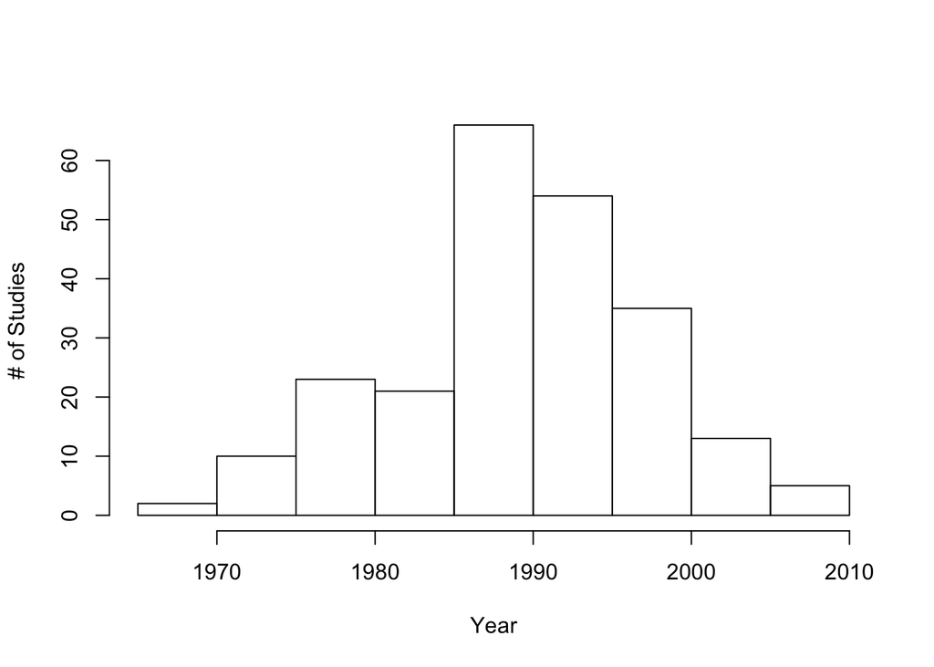

This pattern suggests that the number of surveys is declining through time, or that there is less interest in submitting survey data to the NVD, or (most likely) both.

A histogram of plot sizes:

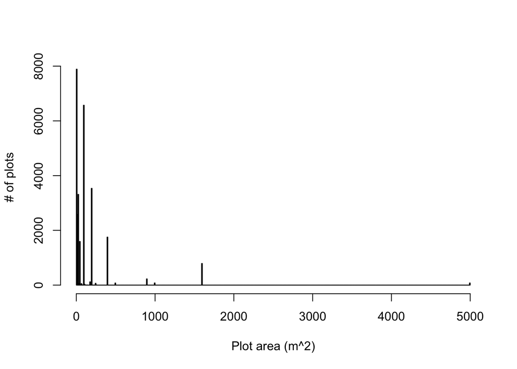

What about representation of plots in the National Vegetation Map (2012) vegetation types (447 altogether)?

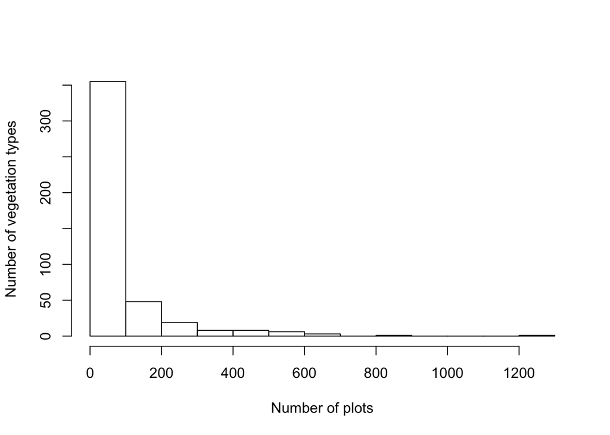

There are 84 veg types without any plot data, 148 with less than 5 plots, and 193 with less than 10 plots…

If we consider the 44822 mapped polygons (there are multiple polygons per veg type), there are 43567 polygons without any plot data, 44264 with less than 5 plots, and 44432 with less than 10 plots…

But! 3387 of the 33401 plots with spatial information are now in transformed landscapes according to the 2013 National Land Cover. So let’s look at the stats for veg types again, excluding transformed plots…

There are 93 veg types without any plot data, 159 with less than 5 plots, and 200 with less than 10 plots…

Now let’s look at the density of sampling (# plots/Ha) by polygon where red is low sampling and bright yellow is high sampling.

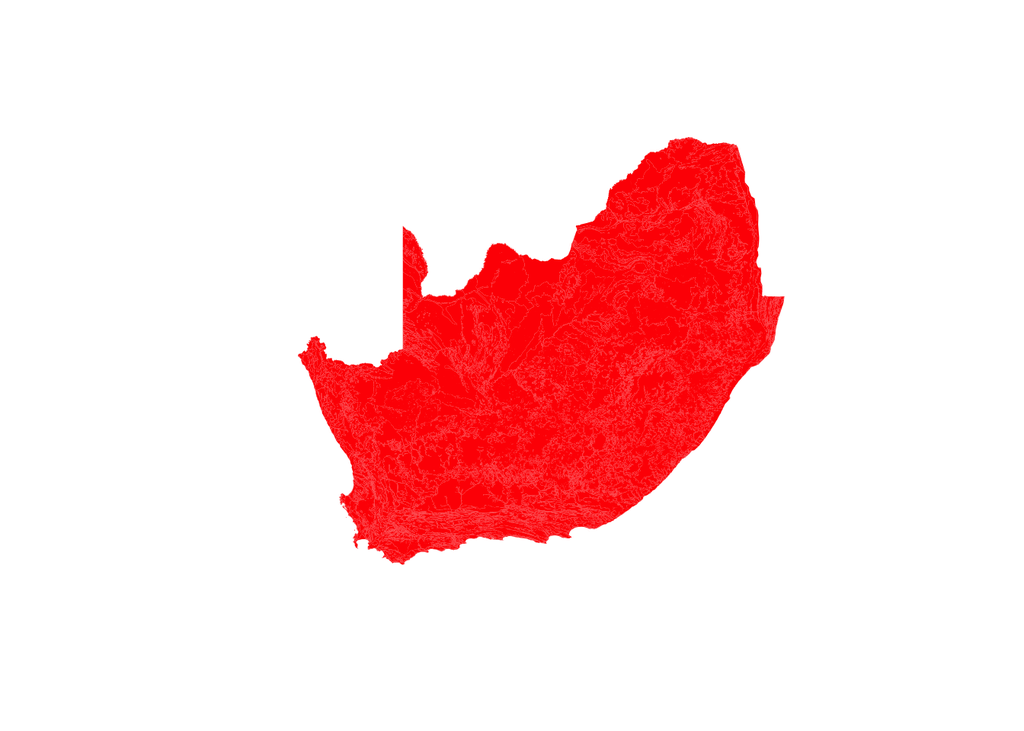

*THERE’S LOT OF WORK TO DO!!!*